# Risk Factor Analysis

## Outcome Variable

**Outcome Variable:** ever_co

## Predictor Variables

**Intervention Variable:** exclfeed6

**Adjustment Set:**

- arm
- sex
- brthmon
- W_mage
- meducyrs
- feducyrs
- hhwealth_quart
- hfoodsec
- W_mhtcm
- W_mwtkg
- W_mbmi
- vagbrth
- W_gagebrth
- W_birthwt
- W_birthlen
- W_nrooms
- W_nchldlt5
- month
- W_parity
- impfloor
- impsan
- safeh20
- delta_W_mage
- delta_meducyrs
- delta_feducyrs
- delta_hhwealth_quart
- delta_hfoodsec
- delta_W_mhtcm
- delta_W_mwtkg
- delta_W_mbmi
- delta_vagbrth
- delta_W_gagebrth
- delta_W_birthwt
- delta_W_birthlen
- delta_W_nrooms
- delta_W_nchldlt5
- delta_month
- delta_W_parity
- delta_impfloor
- delta_impsan
- delta_safeh20

## Stratifying Variables

The analysis was stratified on these variable(s):

- agecat
- studyid
- country

## Data Summary

| agecat | studyid | country | exclfeed6 | ever_co | n_cell | n |
| --- | --- | --- | --- | --- | --- | --- |
| 0-24 months | CMC-V-BCS-2002 | INDIA | 1 | 0 | 15 | 19 |
| 0-24 months | CMC-V-BCS-2002 | INDIA | 1 | 1 | 4 | 19 |
| 0-24 months | CMC-V-BCS-2002 | INDIA | 0 | 0 | 0 | 19 |
| 0-24 months | CMC-V-BCS-2002 | INDIA | 0 | 1 | 0 | 19 |
| 0-24 months | EE | PAKISTAN | 1 | 0 | 20 | 48 |
| 0-24 months | EE | PAKISTAN | 1 | 1 | 23 | 48 |
| 0-24 months | EE | PAKISTAN | 0 | 0 | 5 | 48 |
| 0-24 months | EE | PAKISTAN | 0 | 1 | 0 | 48 |
| 0-24 months | GMS-Nepal | NEPAL | 1 | 0 | 279 | 565 |
| 0-24 months | GMS-Nepal | NEPAL | 1 | 1 | 141 | 565 |
| 0-24 months | GMS-Nepal | NEPAL | 0 | 0 | 93 | 565 |
| 0-24 months | GMS-Nepal | NEPAL | 0 | 1 | 52 | 565 |
| 0-24 months | IRC | INDIA | 1 | 0 | 0 | 14 |
| 0-24 months | IRC | INDIA | 1 | 1 | 0 | 14 |
| 0-24 months | IRC | INDIA | 0 | 0 | 12 | 14 |
| 0-24 months | IRC | INDIA | 0 | 1 | 2 | 14 |
| 0-24 months | JiVitA-3 | BANGLADESH | 1 | 0 | 11264 | 15902 |
| 0-24 months | JiVitA-3 | BANGLADESH | 1 | 1 | 1116 | 15902 |
| 0-24 months | JiVitA-3 | BANGLADESH | 0 | 0 | 3182 | 15902 |
| 0-24 months | JiVitA-3 | BANGLADESH | 0 | 1 | 340 | 15902 |
| 0-24 months | JiVitA-4 | BANGLADESH | 1 | 0 | 3141 | 4753 |
| 0-24 months | JiVitA-4 | BANGLADESH | 1 | 1 | 548 | 4753 |
| 0-24 months | JiVitA-4 | BANGLADESH | 0 | 0 | 847 | 4753 |
| 0-24 months | JiVitA-4 | BANGLADESH | 0 | 1 | 217 | 4753 |
| 0-24 months | Keneba | GAMBIA | 1 | 0 | 719 | 2235 |
| 0-24 months | Keneba | GAMBIA | 1 | 1 | 107 | 2235 |
| 0-24 months | Keneba | GAMBIA | 0 | 0 | 1145 | 2235 |
| 0-24 months | Keneba | GAMBIA | 0 | 1 | 264 | 2235 |
| 0-24 months | LCNI-5 | MALAWI | 1 | 0 | 44 | 272 |
| 0-24 months | LCNI-5 | MALAWI | 1 | 1 | 3 | 272 |

[output cut: 186 more lines]

The following strata were considered:

- agecat: 0-24 months, studyid: CMC-V-BCS-2002, country: INDIA
- agecat: 0-24 months, studyid: EE, country: PAKISTAN
- agecat: 0-24 months, studyid: GMS-Nepal, country: NEPAL
- agecat: 0-24 months, studyid: IRC, country: INDIA
- agecat: 0-24 months, studyid: JiVitA-3, country: BANGLADESH
- agecat: 0-24 months, studyid: JiVitA-4, country: BANGLADESH
- agecat: 0-24 months, studyid: Keneba, country: GAMBIA
- agecat: 0-24 months, studyid: LCNI-5, country: MALAWI
- agecat: 0-24 months, studyid: MAL-ED, country: BANGLADESH
- agecat: 0-24 months, studyid: MAL-ED, country: BRAZIL
- agecat: 0-24 months, studyid: MAL-ED, country: INDIA
- agecat: 0-24 months, studyid: MAL-ED, country: NEPAL
- agecat: 0-24 months, studyid: MAL-ED, country: PERU
- agecat: 0-24 months, studyid: MAL-ED, country: SOUTH AFRICA
- agecat: 0-24 months, studyid: MAL-ED, country: TANZANIA, UNITED REPUBLIC OF
- agecat: 0-24 months, studyid: PROVIDE, country: BANGLADESH
- agecat: 0-24 months, studyid: SAS-CompFeed, country: INDIA
- agecat: 0-24 months, studyid: SAS-FoodSuppl, country: INDIA
- agecat: 0-6 months, studyid: CMC-V-BCS-2002, country: INDIA
- agecat: 0-6 months, studyid: EE, country: PAKISTAN
- agecat: 0-6 months, studyid: GMS-Nepal, country: NEPAL
- agecat: 0-6 months, studyid: IRC, country: INDIA
- agecat: 0-6 months, studyid: JiVitA-3, country: BANGLADESH
- agecat: 0-6 months, studyid: JiVitA-4, country: BANGLADESH
- agecat: 0-6 months, studyid: Keneba, country: GAMBIA
- agecat: 0-6 months, studyid: LCNI-5, country: MALAWI
- agecat: 0-6 months, studyid: MAL-ED, country: BANGLADESH
- agecat: 0-6 months, studyid: MAL-ED, country: BRAZIL
- agecat: 0-6 months, studyid: MAL-ED, country: INDIA
- agecat: 0-6 months, studyid: MAL-ED, country: NEPAL
- agecat: 0-6 months, studyid: MAL-ED, country: PERU
- agecat: 0-6 months, studyid: MAL-ED, country: SOUTH AFRICA
- agecat: 0-6 months, studyid: MAL-ED, country: TANZANIA, UNITED REPUBLIC OF
- agecat: 0-6 months, studyid: PROVIDE, country: BANGLADESH
- agecat: 0-6 months, studyid: SAS-CompFeed, country: INDIA
- agecat: 0-6 months, studyid: SAS-FoodSuppl, country: INDIA
- agecat: 6-24 months, studyid: CMC-V-BCS-2002, country: INDIA
- agecat: 6-24 months, studyid: EE, country: PAKISTAN
- agecat: 6-24 months, studyid: GMS-Nepal, country: NEPAL
- agecat: 6-24 months, studyid: IRC, country: INDIA
- agecat: 6-24 months, studyid: JiVitA-3, country: BANGLADESH
- agecat: 6-24 months, studyid: JiVitA-4, country: BANGLADESH
- agecat: 6-24 months, studyid: Keneba, country: GAMBIA
- agecat: 6-24 months, studyid: LCNI-5, country: MALAWI
- agecat: 6-24 months, studyid: MAL-ED, country: BANGLADESH
- agecat: 6-24 months, studyid: MAL-ED, country: BRAZIL
- agecat: 6-24 months, studyid: MAL-ED, country: INDIA
- agecat: 6-24 months, studyid: MAL-ED, country: NEPAL
- agecat: 6-24 months, studyid: MAL-ED, country: PERU
- agecat: 6-24 months, studyid: MAL-ED, country: SOUTH AFRICA
- agecat: 6-24 months, studyid: MAL-ED, country: TANZANIA, UNITED REPUBLIC OF
- agecat: 6-24 months, studyid: PROVIDE, country: BANGLADESH
- agecat: 6-24 months, studyid: SAS-CompFeed, country: INDIA
- agecat: 6-24 months, studyid: SAS-FoodSuppl, country: INDIA

### Dropped Strata

Some strata were dropped due to rare outcomes:

- agecat: 0-24 months, studyid: CMC-V-BCS-2002, country: INDIA
- agecat: 0-24 months, studyid: EE, country: PAKISTAN
- agecat: 0-24 months, studyid: IRC, country: INDIA
- agecat: 0-24 months, studyid: LCNI-5, country: MALAWI
- agecat: 0-24 months, studyid: MAL-ED, country: BRAZIL
- agecat: 0-24 months, studyid: MAL-ED, country: INDIA
- agecat: 0-24 months, studyid: MAL-ED, country: NEPAL
- agecat: 0-24 months, studyid: MAL-ED, country: PERU
- agecat: 0-24 months, studyid: MAL-ED, country: SOUTH AFRICA
- agecat: 0-24 months, studyid: MAL-ED, country: TANZANIA, UNITED REPUBLIC OF
- agecat: 0-24 months, studyid: SAS-FoodSuppl, country: INDIA
- agecat: 0-6 months, studyid: CMC-V-BCS-2002, country: INDIA
- agecat: 0-6 months, studyid: EE, country: PAKISTAN
- agecat: 0-6 months, studyid: IRC, country: INDIA
- agecat: 0-6 months, studyid: LCNI-5, country: MALAWI
- agecat: 0-6 months, studyid: MAL-ED, country: BANGLADESH
- agecat: 0-6 months, studyid: MAL-ED, country: BRAZIL
- agecat: 0-6 months, studyid: MAL-ED, country: INDIA
- agecat: 0-6 months, studyid: MAL-ED, country: NEPAL
- agecat: 0-6 months, studyid: MAL-ED, country: PERU
- agecat: 0-6 months, studyid: MAL-ED, country: SOUTH AFRICA
- agecat: 0-6 months, studyid: MAL-ED, country: TANZANIA, UNITED REPUBLIC OF
- agecat: 0-6 months, studyid: PROVIDE, country: BANGLADESH
- agecat: 0-6 months, studyid: SAS-CompFeed, country: INDIA
- agecat: 0-6 months, studyid: SAS-FoodSuppl, country: INDIA
- agecat: 6-24 months, studyid: CMC-V-BCS-2002, country: INDIA
- agecat: 6-24 months, studyid: EE, country: PAKISTAN
- agecat: 6-24 months, studyid: IRC, country: INDIA
- agecat: 6-24 months, studyid: LCNI-5, country: MALAWI
- agecat: 6-24 months, studyid: MAL-ED, country: BRAZIL
- agecat: 6-24 months, studyid: MAL-ED, country: INDIA
- agecat: 6-24 months, studyid: MAL-ED, country: NEPAL
- agecat: 6-24 months, studyid: MAL-ED, country: PERU
- agecat: 6-24 months, studyid: MAL-ED, country: SOUTH AFRICA
- agecat: 6-24 months, studyid: MAL-ED, country: TANZANIA, UNITED REPUBLIC OF
- agecat: 6-24 months, studyid: SAS-FoodSuppl, country: INDIA

## Methods Detail

We’re interested in the causal parameters $E[Y_a]$ for all values of $a \in \mathcal{A}$. These parameters represent the mean outcome if, possibly contrary to fact, we intervened to set all units to have $A=a$. Under the randomization and positivity assumptions, these are identified by the statistical parameters $\psi_a=E_W[E_{Y|A,W}(Y|A=a,W)]$. In addition, we’re interested in the mean of $Y$, $E[Y]$ under no intervention (the observed mean). We will estimate these parameters by using SuperLearner to fit the relevant likelihood factors – $E_{Y|A,W}(Y|A=a,W)$ and $p(A=a|W)$, and then updating our likelihood fit using a joint TMLE.

For unadjusted analyses ($W=\{\}$), initial likelihoods were estimated using Lrnr_glm to estimate the simple $E(Y|A)$ and Lrnr_mean to estimate $p(A)$. For adjusted analyses, a small library containing Lrnr_glmnet, Lrnr_xgboost, and Lrnr_mean was used.

Having estimated these parameters, we will then use the delta method to estimate relative risks and attributable risks relative to a prespecified baseline level of $A$.

# Results Detail

## Results Plots

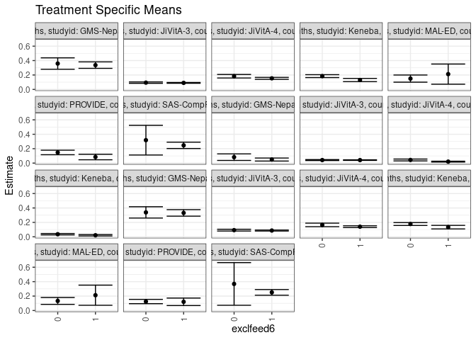

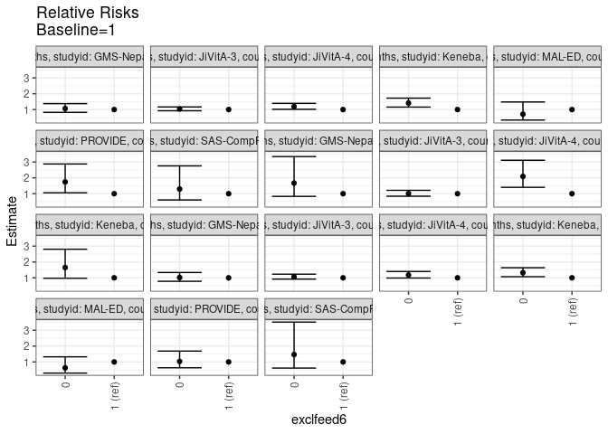

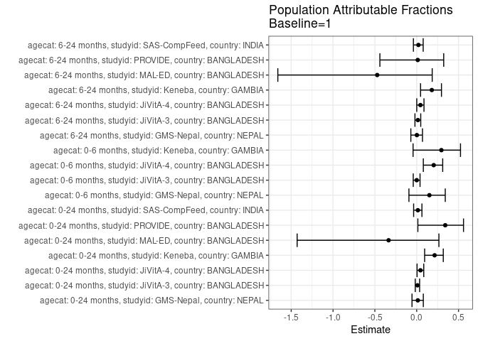

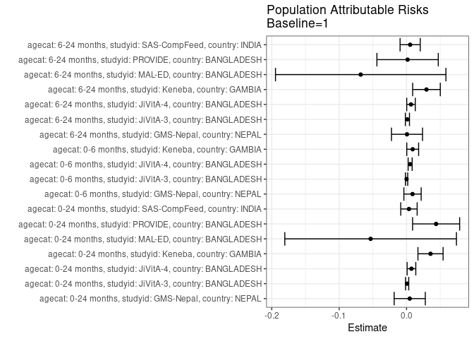

## Results Table

### Parameter: TSM

| agecat | studyid | country | intervention_level | baseline_level | estimate | ci_lower | ci_upper |
| --- | --- | --- | --- | --- | --- | --- | --- |
| 0-24 months | GMS-Nepal | NEPAL | 1 | NA | 0.3368749 | 0.2919252 | 0.3818245 |
| 0-24 months | GMS-Nepal | NEPAL | 0 | NA | 0.3586829 | 0.2795716 | 0.4377941 |
| 0-24 months | JiVitA-3 | BANGLADESH | 1 | NA | 0.0907293 | 0.0853090 | 0.0961497 |
| 0-24 months | JiVitA-3 | BANGLADESH | 0 | NA | 0.0941075 | 0.0844322 | 0.1037828 |
| 0-24 months | JiVitA-4 | BANGLADESH | 1 | NA | 0.1536885 | 0.1405375 | 0.1668394 |
| 0-24 months | JiVitA-4 | BANGLADESH | 0 | NA | 0.1828622 | 0.1585091 | 0.2072153 |
| 0-24 months | Keneba | GAMBIA | 1 | NA | 0.1304379 | 0.1081329 | 0.1527429 |
| 0-24 months | Keneba | GAMBIA | 0 | NA | 0.1841127 | 0.1641071 | 0.2041183 |
| 0-24 months | MAL-ED | BANGLADESH | 1 | NA | 0.2121212 | 0.0723406 | 0.3519018 |
| 0-24 months | MAL-ED | BANGLADESH | 0 | NA | 0.1500000 | 0.1004068 | 0.1995932 |
| 0-24 months | PROVIDE | BANGLADESH | 1 | NA | 0.0847175 | 0.0463616 | 0.1230735 |
| 0-24 months | PROVIDE | BANGLADESH | 0 | NA | 0.1477147 | 0.1162424 | 0.1791870 |
| 0-24 months | SAS-CompFeed | INDIA | 1 | NA | 0.2464455 | 0.2022875 | 0.2906035 |
| 0-24 months | SAS-CompFeed | INDIA | 0 | NA | 0.3181818 | 0.1124254 | 0.5239382 |
| 0-6 months | GMS-Nepal | NEPAL | 1 | NA | 0.0495487 | 0.0286843 | 0.0704130 |
| 0-6 months | GMS-Nepal | NEPAL | 0 | NA | 0.0826863 | 0.0372081 | 0.1281646 |
| 0-6 months | JiVitA-3 | BANGLADESH | 1 | NA | 0.0417655 | 0.0378730 | 0.0456581 |
| 0-6 months | JiVitA-3 | BANGLADESH | 0 | NA | 0.0421792 | 0.0356097 | 0.0487488 |
| 0-6 months | JiVitA-4 | BANGLADESH | 1 | NA | 0.0208325 | 0.0150246 | 0.0266404 |
| 0-6 months | JiVitA-4 | BANGLADESH | 0 | NA | 0.0435142 | 0.0305863 | 0.0564420 |
| 0-6 months | Keneba | GAMBIA | 1 | NA | 0.0217645 | 0.0118369 | 0.0316920 |
| 0-6 months | Keneba | GAMBIA | 0 | NA | 0.0359119 | 0.0262060 | 0.0456177 |
| 6-24 months | GMS-Nepal | NEPAL | 1 | NA | 0.3314787 | 0.2861533 | 0.3768041 |
| 6-24 months | GMS-Nepal | NEPAL | 0 | NA | 0.3385394 | 0.2601179 | 0.4169608 |
| 6-24 months | JiVitA-3 | BANGLADESH | 1 | NA | 0.0869387 | 0.0803025 | 0.0935748 |
| 6-24 months | JiVitA-3 | BANGLADESH | 0 | NA | 0.0922917 | 0.0799860 | 0.1045975 |
| 6-24 months | JiVitA-4 | BANGLADESH | 1 | NA | 0.1402195 | 0.1277593 | 0.1526798 |
| 6-24 months | JiVitA-4 | BANGLADESH | 0 | NA | 0.1646837 | 0.1401696 | 0.1891979 |
| 6-24 months | Keneba | GAMBIA | 1 | NA | 0.1340850 | 0.1096910 | 0.1584789 |
| 6-24 months | Keneba | GAMBIA | 0 | NA | 0.1773463 | 0.1572859 | 0.1974066 |
| 6-24 months | MAL-ED | BANGLADESH | 1 | NA | 0.2121212 | 0.0723354 | 0.3519071 |
| 6-24 months | MAL-ED | BANGLADESH | 0 | NA | 0.1326531 | 0.0850620 | 0.1802441 |
| 6-24 months | PROVIDE | BANGLADESH | 1 | NA | 0.1206198 | 0.0688443 | 0.1723953 |
| 6-24 months | PROVIDE | BANGLADESH | 0 | NA | 0.1243318 | 0.0943689 | 0.1542946 |
| 6-24 months | SAS-CompFeed | INDIA | 1 | NA | 0.2512563 | 0.2120897 | 0.2904228 |
| 6-24 months | SAS-CompFeed | INDIA | 0 | NA | 0.3684211 | 0.0727072 | 0.6641349 |

### Parameter: E(Y)

| agecat | studyid | country | intervention_level | baseline_level | estimate | ci_lower | ci_upper |
| --- | --- | --- | --- | --- | --- | --- | --- |
| 0-24 months | GMS-Nepal | NEPAL | NA | NA | 0.3415929 | 0.3024539 | 0.3807320 |
| 0-24 months | JiVitA-3 | BANGLADESH | NA | NA | 0.0915608 | 0.0867079 | 0.0964137 |
| 0-24 months | JiVitA-4 | BANGLADESH | NA | NA | 0.1609510 | 0.1491579 | 0.1727440 |
| 0-24 months | Keneba | GAMBIA | NA | NA | 0.1659955 | 0.1505665 | 0.1814246 |
| 0-24 months | MAL-ED | BANGLADESH | NA | NA | 0.1587983 | 0.1117681 | 0.2058285 |
| 0-24 months | PROVIDE | BANGLADESH | NA | NA | 0.1285714 | 0.1037574 | 0.1533855 |
| 0-24 months | SAS-CompFeed | INDIA | NA | NA | 0.2500000 | 0.2118239 | 0.2881761 |
| 0-6 months | GMS-Nepal | NEPAL | NA | NA | 0.0584071 | 0.0390530 | 0.0777612 |
| 0-6 months | JiVitA-3 | BANGLADESH | NA | NA | 0.0417690 | 0.0384207 | 0.0451174 |
| 0-6 months | JiVitA-4 | BANGLADESH | NA | NA | 0.0261535 | 0.0207066 | 0.0316005 |
| 0-6 months | Keneba | GAMBIA | NA | NA | 0.0308725 | 0.0236998 | 0.0380452 |
| 6-24 months | GMS-Nepal | NEPAL | NA | NA | 0.3321364 | 0.2929882 | 0.3712847 |
| 6-24 months | JiVitA-3 | BANGLADESH | NA | NA | 0.0882064 | 0.0821266 | 0.0942862 |
| 6-24 months | JiVitA-4 | BANGLADESH | NA | NA | 0.1468045 | 0.1358635 | 0.1577455 |
| 6-24 months | Keneba | GAMBIA | NA | NA | 0.1636364 | 0.1477722 | 0.1795005 |
| 6-24 months | MAL-ED | BANGLADESH | NA | NA | 0.1441048 | 0.0985189 | 0.1896907 |
| 6-24 months | PROVIDE | BANGLADESH | NA | NA | 0.1221498 | 0.0962275 | 0.1480722 |
| 6-24 months | SAS-CompFeed | INDIA | NA | NA | 0.2565947 | 0.2209578 | 0.2922316 |

### Parameter: RR

| agecat | studyid | country | intervention_level | baseline_level | estimate | ci_lower | ci_upper |
| --- | --- | --- | --- | --- | --- | --- | --- |
| 0-24 months | GMS-Nepal | NEPAL | 1 | 1 | 1.0000000 | 1.0000000 | 1.000000 |
| 0-24 months | GMS-Nepal | NEPAL | 0 | 1 | 1.0647361 | 0.8236395 | 1.376407 |
| 0-24 months | JiVitA-3 | BANGLADESH | 1 | 1 | 1.0000000 | 1.0000000 | 1.000000 |
| 0-24 months | JiVitA-3 | BANGLADESH | 0 | 1 | 1.0372338 | 0.9239633 | 1.164390 |
| 0-24 months | JiVitA-4 | BANGLADESH | 1 | 1 | 1.0000000 | 1.0000000 | 1.000000 |
| 0-24 months | JiVitA-4 | BANGLADESH | 0 | 1 | 1.1898239 | 1.0181040 | 1.390507 |
| 0-24 months | Keneba | GAMBIA | 1 | 1 | 1.0000000 | 1.0000000 | 1.000000 |
| 0-24 months | Keneba | GAMBIA | 0 | 1 | 1.4114967 | 1.1566482 | 1.722497 |
| 0-24 months | MAL-ED | BANGLADESH | 1 | 1 | 1.0000000 | 1.0000000 | 1.000000 |
| 0-24 months | MAL-ED | BANGLADESH | 0 | 1 | 0.7071429 | 0.3383148 | 1.478064 |
| 0-24 months | PROVIDE | BANGLADESH | 1 | 1 | 1.0000000 | 1.0000000 | 1.000000 |
| 0-24 months | PROVIDE | BANGLADESH | 0 | 1 | 1.7436138 | 1.0574338 | 2.875063 |
| 0-24 months | SAS-CompFeed | INDIA | 1 | 1 | 1.0000000 | 1.0000000 | 1.000000 |
| 0-24 months | SAS-CompFeed | INDIA | 0 | 1 | 1.2910839 | 0.6050646 | 2.754908 |
| 0-6 months | GMS-Nepal | NEPAL | 1 | 1 | 1.0000000 | 1.0000000 | 1.000000 |
| 0-6 months | GMS-Nepal | NEPAL | 0 | 1 | 1.6687909 | 0.8330252 | 3.343072 |
| 0-6 months | JiVitA-3 | BANGLADESH | 1 | 1 | 1.0000000 | 1.0000000 | 1.000000 |
| 0-6 months | JiVitA-3 | BANGLADESH | 0 | 1 | 1.0099055 | 0.8416208 | 1.211839 |
| 0-6 months | JiVitA-4 | BANGLADESH | 1 | 1 | 1.0000000 | 1.0000000 | 1.000000 |
| 0-6 months | JiVitA-4 | BANGLADESH | 0 | 1 | 2.0887639 | 1.4034683 | 3.108680 |
| 0-6 months | Keneba | GAMBIA | 1 | 1 | 1.0000000 | 1.0000000 | 1.000000 |
| 0-6 months | Keneba | GAMBIA | 0 | 1 | 1.6500224 | 0.9709508 | 2.804029 |
| 6-24 months | GMS-Nepal | NEPAL | 1 | 1 | 1.0000000 | 1.0000000 | 1.000000 |
| 6-24 months | GMS-Nepal | NEPAL | 0 | 1 | 1.0213005 | 0.7803912 | 1.336579 |
| 6-24 months | JiVitA-3 | BANGLADESH | 1 | 1 | 1.0000000 | 1.0000000 | 1.000000 |
| 6-24 months | JiVitA-3 | BANGLADESH | 0 | 1 | 1.0615727 | 0.9166760 | 1.229373 |
| 6-24 months | JiVitA-4 | BANGLADESH | 1 | 1 | 1.0000000 | 1.0000000 | 1.000000 |
| 6-24 months | JiVitA-4 | BANGLADESH | 0 | 1 | 1.1744705 | 0.9854072 | 1.399808 |
| 6-24 months | Keneba | GAMBIA | 1 | 1 | 1.0000000 | 1.0000000 | 1.000000 |
| 6-24 months | Keneba | GAMBIA | 0 | 1 | 1.3226409 | 1.0702904 | 1.634490 |
| 6-24 months | MAL-ED | BANGLADESH | 1 | 1 | 1.0000000 | 1.0000000 | 1.000000 |
| 6-24 months | MAL-ED | BANGLADESH | 0 | 1 | 0.6253644 | 0.2953068 | 1.324320 |
| 6-24 months | PROVIDE | BANGLADESH | 1 | 1 | 1.0000000 | 1.0000000 | 1.000000 |
| 6-24 months | PROVIDE | BANGLADESH | 0 | 1 | 1.0307742 | 0.6302931 | 1.685717 |
| 6-24 months | SAS-CompFeed | INDIA | 1 | 1 | 1.0000000 | 1.0000000 | 1.000000 |
| 6-24 months | SAS-CompFeed | INDIA | 0 | 1 | 1.4663158 | 0.6118309 | 3.514177 |

### Parameter: PAR

| agecat | studyid | country | intervention_level | baseline_level | estimate | ci_lower | ci_upper |
| --- | --- | --- | --- | --- | --- | --- | --- |
| 0-24 months | GMS-Nepal | NEPAL | 1 | NA | 0.0047180 | -0.0183830 | 0.0278191 |
| 0-24 months | JiVitA-3 | BANGLADESH | 1 | NA | 0.0008315 | -0.0015607 | 0.0032237 |
| 0-24 months | JiVitA-4 | BANGLADESH | 1 | NA | 0.0072625 | 0.0008197 | 0.0137053 |
| 0-24 months | Keneba | GAMBIA | 1 | NA | 0.0355576 | 0.0169077 | 0.0542076 |
| 0-24 months | MAL-ED | BANGLADESH | 1 | NA | -0.0533229 | -0.1806646 | 0.0740188 |
| 0-24 months | PROVIDE | BANGLADESH | 1 | NA | 0.0438539 | 0.0089472 | 0.0787605 |
| 0-24 months | SAS-CompFeed | INDIA | 1 | NA | 0.0035545 | -0.0086130 | 0.0157220 |
| 0-6 months | GMS-Nepal | NEPAL | 1 | NA | 0.0088584 | -0.0039684 | 0.0216852 |
| 0-6 months | JiVitA-3 | BANGLADESH | 1 | NA | 0.0000035 | -0.0016925 | 0.0016995 |
| 0-6 months | JiVitA-4 | BANGLADESH | 1 | NA | 0.0053210 | 0.0023441 | 0.0082980 |
| 0-6 months | Keneba | GAMBIA | 1 | NA | 0.0091080 | 0.0003202 | 0.0178958 |
| 6-24 months | GMS-Nepal | NEPAL | 1 | NA | 0.0006577 | -0.0223951 | 0.0237106 |
| 6-24 months | JiVitA-3 | BANGLADESH | 1 | NA | 0.0012678 | -0.0017875 | 0.0043230 |
| 6-24 months | JiVitA-4 | BANGLADESH | 1 | NA | 0.0065849 | 0.0002498 | 0.0129200 |
| 6-24 months | Keneba | GAMBIA | 1 | NA | 0.0295514 | 0.0090426 | 0.0500602 |
| 6-24 months | MAL-ED | BANGLADESH | 1 | NA | -0.0680164 | -0.1944542 | 0.0584214 |
| 6-24 months | PROVIDE | BANGLADESH | 1 | NA | 0.0015301 | -0.0439913 | 0.0470514 |
| 6-24 months | SAS-CompFeed | INDIA | 1 | NA | 0.0053384 | -0.0095993 | 0.0202761 |

### Parameter: PAF

| agecat | studyid | country | intervention_level | baseline_level | estimate | ci_lower | ci_upper |
| --- | --- | --- | --- | --- | --- | --- | --- |
| 0-24 months | GMS-Nepal | NEPAL | 1 | NA | 0.0138118 | -0.0561659 | 0.0791531 |
| 0-24 months | JiVitA-3 | BANGLADESH | 1 | NA | 0.0090814 | -0.0173995 | 0.0348732 |
| 0-24 months | JiVitA-4 | BANGLADESH | 1 | NA | 0.0451224 | 0.0042727 | 0.0842963 |
| 0-24 months | Keneba | GAMBIA | 1 | NA | 0.2142084 | 0.0949266 | 0.3177698 |
| 0-24 months | MAL-ED | BANGLADESH | 1 | NA | -0.3357903 | -1.4291848 | 0.2654590 |
| 0-24 months | PROVIDE | BANGLADESH | 1 | NA | 0.3410857 | 0.0139488 | 0.5596902 |
| 0-24 months | SAS-CompFeed | INDIA | 1 | NA | 0.0142180 | -0.0365627 | 0.0625110 |
| 0-6 months | GMS-Nepal | NEPAL | 1 | NA | 0.1516670 | -0.0927786 | 0.3414321 |
| 0-6 months | JiVitA-3 | BANGLADESH | 1 | NA | 0.0000838 | -0.0413563 | 0.0398749 |
| 0-6 months | JiVitA-4 | BANGLADESH | 1 | NA | 0.2034535 | 0.0792409 | 0.3109095 |
| 0-6 months | Keneba | GAMBIA | 1 | NA | 0.2950202 | -0.0434081 | 0.5236796 |
| 6-24 months | GMS-Nepal | NEPAL | 1 | NA | 0.0019803 | -0.0698970 | 0.0690288 |
| 6-24 months | JiVitA-3 | BANGLADESH | 1 | NA | 0.0143726 | -0.0208334 | 0.0483643 |
| 6-24 months | JiVitA-4 | BANGLADESH | 1 | NA | 0.0448551 | 0.0006921 | 0.0870663 |
| 6-24 months | Keneba | GAMBIA | 1 | NA | 0.1805919 | 0.0461665 | 0.2960725 |
| 6-24 months | MAL-ED | BANGLADESH | 1 | NA | -0.4719927 | -1.6599630 | 0.1854164 |
| 6-24 months | PROVIDE | BANGLADESH | 1 | NA | 0.0125260 | -0.4401210 | 0.3229007 |
| 6-24 months | SAS-CompFeed | INDIA | 1 | NA | 0.0208050 | -0.0393691 | 0.0774953 |